# Wohin zieht es durch Postdoc.Mobility geförderte Forschende? Europa liegt im Trend

13.07.2022

**Jedes Jahr fördert der SNF Hunderte von jungen Forschenden, die für einen mehrjährigen Forschungsaufenthalt ins Ausland gehen. Doch wo genau gehen sie hin?**

Die meisten dieser Forschenden haben in der Schweiz ein Doktorat oder einen medizinischen Abschluss erworben. Anschliessend gehen sie mit einem [Postdoc.Mobility-Stipendium](http://www.snf.ch/en/funding/careers/postdoc-mobility/Pages/default.aspx) des SNF ins Ausland, wo sie ihre Forschung fortsetzen. Der durchschnittliche Förderbeitrag des auf zwei Jahre ausgelegten Stipendiums belief sich 2021 auf 107’000 Franken. Ziel dieser rund 400 Aufenthalte pro Jahr ist es, bestehendes Wissen der Forschenden zu vertiefen, die wissenschaftliche Unabhängigkeit zu stärken und das Profil zu schärfen, bevor die Rückkehr in die Schweiz für die weitere Laufbahn erfolgt. Solche Aufenthalte tragen auch zur Vernetzung der Schweiz mit der internationalen Forschungsgemeinschaft bei.

### Meistbesuchte Länder

Die nachfolgende Abbildung zeigt, welche Zielländer zwischen 2005 und 2021 im Rahmen von Postdoc.Mobility-Stipendien am häufigsten besucht wurden. Vier der sechs meistbesuchten Länder sind englischsprachig, die anderen beiden sind Deutschland und Frankreich.

Meistbesuchte Gastländer von Postdoc.Mobility

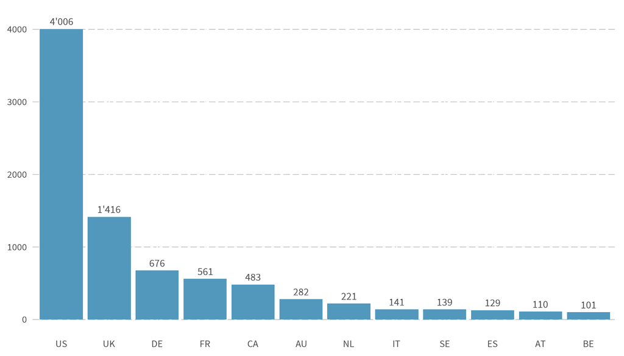

Alle Aufenthalte in Postdoc.Mobility-Gastländern zwischen 2005 und 2021.

### Trends im Verlauf der Jahre

Die USA werden nach wie vor mit Abstand am häufigsten besucht, der Trend zeigt jedoch seit 2013 nach unten. Dieser Rückgang könnte teilweise auf die politische Situation mit einer restriktiveren Einwanderungspolitik zurückzuführen sein. Interessanterweise ist die Zahl der Postdoc.Mobility-Aufenthalte in Grossbritannien mehr oder weniger stabil geblieben, auch nach dem Brexit. Daneben ist ganz Kontinentaleuropa in der Gunst der Beitragsempfangenden gestiegen, was sich in einer steigenden Zahl von Aufenthalten widerspiegelt.

Stipendien in Kontinentaleuropa, in den USA und in Grossbritannien

[interactive chart not shown]

Jährlicher Prozentsatz aller Postdoc.Mobility-Stipendien für Kontinentaleuropa, die USA und Grossbritannien.

Einige Länder mit interessanten Trends sind nachfolgend dargestellt. Frankreich war 2012–2013 sehr gefragt, unmittelbar danach ging die Zahl der Besuche markant zurück. In den letzten Jahren zieht das Land wieder mehr Nachwuchsforschende an. Die niedrigere Zahl von Aufenthalten in den USA ging nicht mit einem Anstieg in anderen englischsprachigen Ländern einher: Sowohl in Kanada als auch in Australien war ein leichter Abwärtstrend zu verzeichnen. Dagegen stieg der Anteil der Aufenthalte in Deutschland, den Niederlanden und Österreich im Allgemeinen.

Für die nicht aufgeführten Länder waren keine speziellen mehrjährigen Trends beim Anteil an den Postdoc.Mobility-Aufenthalten zu beobachten.

Weitere vielbesuchte Länder

[interactive chart not shown]

Jährlicher Anteil der Postdoc.Mobility-Aufenthalte in ausgewählten Ländern. Für die nicht aufgeführten Länder waren keine auffälligen Trends festzustellen.

Die nachfolgende Abbildung zeigt die Zahl der Stipendien nach Kontinenten und Forschungsbereichen (GSW: Geistes- und Sozialwissenschaften, MINT: Mathematik, Natur- und Ingenieurwissenschaften, LW: Lebenswissenschaften). In Nordamerika und Ozeanien ist die Zahl der Stipendien in den Lebenswissenschaften höher, während in den übrigen Kontinenten die Sozial- und Geisteswissenschaften am häufigsten vertreten sind. Besonders niedrig ist die Zahl der Stipendien in Lateinamerika und Afrika. Bei diesen Zahlen wurde Mexiko zu Lateinamerika gezählt.

Stipendien nach Forschungsbereichen und Kontinenten

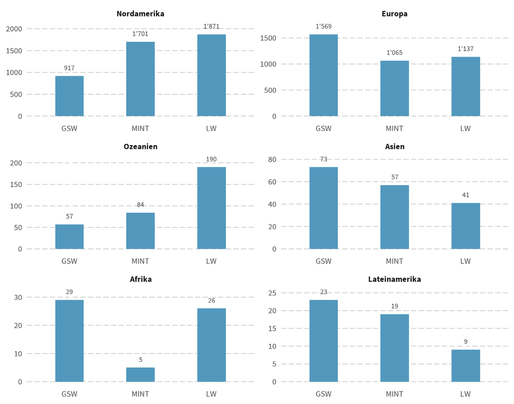

Anzahl der Postdoc.Mobility-Stipendien nach Forschungsbereichen und Kontinenten. Mexiko wurde zu Lateinamerika gerechnet.

Der Anteil der Stipendien für europäische Länder ist in den letzten Jahren gestiegen, der Anteil von Ozeanien und Nordamerika hingegen seit 2015 gesunken. Der Rückgang in Ozeanien nach 2020 ist möglicherweise auch auf die sehr restriktiven Einreisebestimmungen während der Pandemie zurückzuführen, insbesondere in Australien und Neuseeland. Die Zahl der Stipendien für Asien ist relativ gering geblieben.

Stipendien nach Forschungsbereichen auf den vier meistbesuchten Kontinenten im Zeitverlauf

[interactive chart not shown]

Jährlicher prozentualer Anteil der Postdoc.Mobility-Stipendien nach Forschungsbereichen auf den vier meistbesuchten Kontinenten im Laufe des Analysezeitraums. Die übrigen Kontinente sind aufgrund der geringen Anzahl Stipendien nicht dargestellt. Hinweis: Die y-Achse in den beiden Diagrammen in der oberen Reihe weist eine andere Skala auf als in den beiden Diagramme in der unteren Reihe.

Die folgenden Tabellen zeigen, welcher Betrag durchschnittlich nach Kontinent pro Jahr für Postdoc.Mobility-Stipendien vergeben wurde, sowie den Gesamtbetrag, der seit 2005 für die einzelnen Forschungsbereiche und Kontinente vergeben wurde. Wichtig ist der Hinweis, dass die Höhe der Stipendien hauptsächlich von den Lebenshaltungskosten im Zielland abhängt.

Durchschnittlicher Betrag pro Postdoc.Mobility-Stipendium (in Schweizer Franken) nach Kontinent, von 2005–2021

| Kontinent | Durchschnittlicher ausbezahlter Betrag |
| --- | --- |
| Asien | 81’240 |
| Europa | 80’908 |
| Ozeanien | 80’027 |
| Nordamerika | 77’943 |
| Lateinamerika | 74’445 |
| Afrika | 72’261 |

Gesamtbetrag (in Schweizer Franken), der von 2005–2021 für die einzelnen Forschungsbereiche und Kontinente vergeben wurde

| Kontinent | GSW | MINT | LW | Total |
| --- | --- | --- | --- | --- |
| Africa | 2’292’260 | 417’188 | 1’626’228 | 4’335’676 |
| Asien | 6’838’991 | 4’041’537 | 2’930’357 | 13’810’885 |
| Europa | 140’648’041 | 79’320’089 | 84’407’284 | 304’375’414 |
| Lateinamerika | 1’890’886 | 1’255’248 | 650’585 | 3’796’719 |
| Nordamerika | 77’590’288 | 129’508’339 | 141’540’260 | 348’638’887 |
| Ozeanien | 5’727’051 | 6’367’585 | 14’314’342 | 26’408’978 |
| Total | 234’987’517 | 220’909’986 | 245’469’056 | 701’366’559 |

### Rückgang seit 2020

Die Zahlen beinhalten alle Versionen von Postdoc.Mobility-Stipendien, auch die älteren Instrumente Early und Advanced Postdoc.Mobility. Die meisten Postdocs verbringen den gesamten Aufenthalt an einer Institution, etwa ein Sechstel arbeitet an mehreren Orten. In dieser Datenauswertung wird jede Institution separat gezählt; Postdoc.Mobility-Beiträge für die Rückkehr in die Schweiz sind nicht berücksichtigt. Alle Forschenden haben zum Zeitpunkt des Stipendiums ihr Doktorat bereits abgeschlossen und galten als Postdocs. Dass seit 2020 weniger Stipendien vergeben werden, ist einerseits mit dem kleineren Budget im Jahr 2020 und andererseits mit der Zusammenführung von Early Postdoc.Mobility und Postdoc.Mobility im Jahr 2021 zu erklären.

Anzahl Stipendien und insgesamt besuchte internationale Institutionen pro Jahr, 2005–2021

[interactive chart not shown]

Anzahl Postdoc.Mobility-Stipendien und Anzahl besuchte Forschungseinrichtungen im Zeitverlauf.

Weitere Informationen stehen auf dem SNF Datenportal zur Verfügung – im Bereich [Internationalität](https://data.snf.ch/key-figures/internationality) der SNF-Kennzahlen. Der dort verwendete Datensatz beinhaltet auch die Zahlen des Instruments Doc.Mobility.

### Auf den Spuren unserer Postdocs

Der SNF möchte wissen, wie sich die Instrumente der Karriereförderung (inklusive Postdoc.Mobility) auf die Karrieren von Forschenden auswirken. Deshalb hat er 2018 die Studie [Career Tracker Cohorts (SNSF-CTC)](https://careertrackercohorts.ch/) lanciert. Ziel ist es, Informationen über die Karrierewege von Beitragsempfangenden in der Postdoc-Förderung des SNF und über die mittel- und langfristigen Wirkungen der Laufbahnförderung des SNF zu gewinnen.

Daten, Text und der Code zu dieser Data Story sind auf [Github](https://github.com/snsf-data/datastory_fellowships_worldwide) verfügbar und auf [Zenodo](https://doi.org/10.46446/datastory.where-do-our-postdoc-mobility-grantees-go) archiviert. DOI: 10.46446/datastory.where-do-our-postdoc-mobility-grantees-go